# A very quick introduction to vegetation assessments

June 5<sup>th</sup> 2024

## Why do we monitor vegetation?

- Many plant species respond quickly to land management actions
- Serve as indicators of whether an area is moving in a more-or-less desirable direction
- Inform us whether a management action needs to be abandoned, increased, or maintained
- **Serve as the main constituent of habitat quality**
- Note we will **not** cover demography today.

## What variables are typically monitored?

- **Absolute & Relative Cover** *How much of an area has vegetation? How is cover distributed across species and functional groups?*
- preventing erosion, characterizing habitat.
- **Abundance, Frequency, Density** *Are individual plants becoming patchier in areas? Is the population declining?*
  - Are actions too concentrated to microsites? Is a valuable resource declining?
- **Diversity** *How are species in an area distributed? Is an area down to only a few species?*
  - Overall ecosystem integrity, assessing conservation priorities.

## How do we measure plant cover?

- Depends on vegetation type, and annual climatic variability
- Forest
  - Line Intercept
- Grassland & Savannah
  - Line Intercept (LI)
  - Line-Point Intercept (LPI)
  - (Historic) Daubenmire
- Small plants!
  - Grids with equal area cells
  - most subjective of the methods
  - very complicated by when sampling takes place

## How do we measure plant abundance, frequency, and density?

- Belt Transects (abundance)
  - plants are very sparse - pop. census size
  - set up around LPI transects
- Nested Quadrats (frequency)
  - monitor multiple species simultaneously - spatial distribution / stability of populations
  - Daubenmire frames also used
- Quadrats (density)
  - plants are moderately abundant - pop. census size, spatial distribution

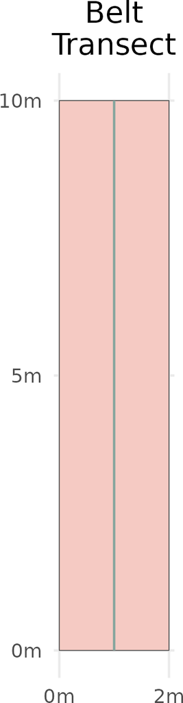

## How do we measure diversity?

- Can be done by wandering around areas…
- Quadrats
  - Generally *much* larger than in other types of sampling
  - Fewer replicates
- Need to be orientated to cross along environmental gradients
- The gold standard: Modified Whittaker
  - MW has two less intensive follow-up variants, the ‘Intensive’ and ‘Extensive’
  - I&E plots can characterize microhabitats (use determined via rarefaction)
  - takes a long time…

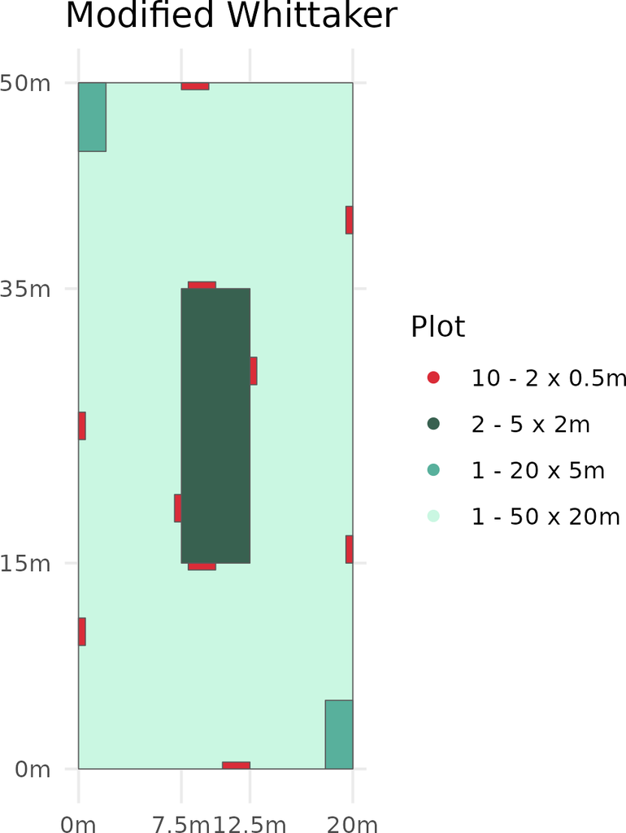

## What is Floristic Quality?

> *‘… tolerance of anthropogenic disturbance and exclusivity to remnant habitats are the only validated criteria for deﬁning FQA.’*

> *‘…FQA conveys two things about high conservative species: (1) All else being equal, they have greater conservation value, and (2) they reﬂect a site’s history of minimal disturbance and degradation.’*
- Useful for identifying high-quality remnant habitat
- Essentially a format for prioritizing land management decisions, especially active management
- We know we cannot restore everywhere, preventing degradation is key, we can shift certain activities to areas of less conservation values

## What do C-values mean?

- Vary by each administrative unit they are generated for
- Reflect the *purpose* of monitoring

> *’… the coefficient applied to each taxon represents a rank based on observed behavior and patterns of occurrence in Illinois plant communities and our confidence that a taxon is remnant (natural area) dependent.*

> *Species given a C value of **0-1** are taxa adapted to severe disturbances, particularly anthropogenic disturbances…*

> *Species with a C value of **2-3** are associated with somewhat more stable, though degraded, environments.*

> *Species with coefficients **4-6** include many dominant or matrix species for several habitats; they have a high consistency of occurrence within given community types.*

> *Species with C values **7-8** are taxa we associate mostly with natural areas, but that can be found persisting where the habitat has been degraded somewhat.*

> *Species with coefficients **9-10** are considered to be restricted to high-quality natural areas.’*

## What do we mean by Species Richness?

- The number of plant taxa in an area; also referred to as gamma-diversity
- Measuring it can be difficult, as many plants are locally rare
- Gamma-diversity, and it’s measurement, is influenced by two main traits
  - the number of species per sub-habitats (alpha-diversity)
  - the turnover in species between sub-habitats (beta-diversity)

## Plot Layout

- Species Richness
  - Rectangular plots capture more species (reviewed in Elzinga et al. 2001)
    - Cross more micro-habitats
- Species Abundance
  - Foliar cover / Basal Cover
    - How much
  - Indicator species, frequency of certain grass species; nested quadrats
    - strength of frequency: unlikely to vary via climate or grazing

## Reading Plots

- Boundary Decisions
  - Are plants rooted?
  - Which side of the plots are plant rooted in?
- Order to reading?
  - Nested quadrats go from smallest to largest plot
    - Only record *new* species along the way
    - If same species is present in ‘2’ as in ‘1’ do not record.
- Avoiding double counting
  - search methodically following a single direction
  - Avoid trampling

## Management Decisions - Species Richness

- Ecosystem resilience often found to relate to the number of species in an area
  - Loss of species may allow proliferation of invasive species

## Management Decisions - FQA

- Should areas with more remnant species be prioritized for active management? *and why*
  - Some species cannot be ‘added’ back in via restoration
  - These areas maybe managed to reduce further anthropogenic impacts, e.g. invasive removal, disallow certain recreation activities.
  - Some areas with higher C-values likely to still harbor rare-species, impetus to survey.
- Use Mean C, or FQI to detect these areas.

## Management Decisions - Species Cover

- Cover of species naturally ebb and flow
- Certain management actions can increase cover of some species, while vastly decreasing cover of others
- Many of the decreasing species may be important for wildlife, or ecosystem function (e.g. water retention, soil stability)

## Management Decisions - Vegetation Similarity

- If we want to *restore* an area, what target area should we use to guide our decisions?
- Can we expect areas with similar vegetation to respond similarly to management actions?
  - e.g. fire, grazing cattle/sheep/goats, removal of invasives?

## Do people really do this?

- Yes, see Benkendorf & Holsinger 2023 for a real life example
  - They use plot based species richness data to determine which factors most affect status of natural areas
  - ca. 860,000 acre area, use spatial statistics and regression techniques to identify features correlating with high FQI
  - Decision:
    - Do we restore areas at less than 7,000 feet?
    - Or do we climate proof ourselves and focus higher?
  - Surprising finding
    - Areas near human habitation doing pretty well…

## Our activity for the early afternoon

- Compare two different parts of McDonald Woods, Upland White Oak & Swamp White Oak
- 1. Determine whether they have different FQI, Mean C, and Wetland Status scores
- 1. Determine how well our quadrats capture the species richness
- 1. Are any portions of each site more similar to the portions of the opposite site?

## Analyses

- Carried out in R version 4.4.0 (2024-04-24) on linux-gnu
- **iNEXT** (Chao et al. 2014, Hsieh et al. 2024) for rarefaction, used to assess sampling completeness.
- **rstatix** (Kassambara 2024) for t.test, used to determine whether differences exist between sites.
- **vegan** (Oksanen et al. 2024) for Non-metric multiDimensional Scaling (NMDS), are portions of sites more similar to each other

## Analysis 1 - Are we capturing a representative amount of the species diversity?

- Not all species are equally common, and detection of locally rare species is difficult
- We can assess sampling completion using rarefaction, and random shuffling of plots
- If the number of species (Y axis), increase greatly via extrapolation, then we should sample more plots

[figure not shown]

## Analysis 2 - Are the two sites notably different?

[figure not shown]

## Analysis 3 - What Quadrat size can we use to determine frequency of indicator species?

- It can be difficult to determine the appropriate plot size for monitoring species
- Nests allow us to try different options readily
- For expedited monitoring carried out across large domains, finding an optimal size is important
- We want a species to show up in 20-80% of plots of various sizes
- our data are pilot data for future monitoring

| Species | Nest | Frequency |
| --- | --- | --- |
| A | 2 | 0.33 |
| B | 1 | 0.42 |
| C | 1 | 0.33 |
| D | 4 | 0.42 |
| E | 3 | 0.33 |
| F | 1 | 0.25 |
| G | 1 | 0.33 |
| H | 1 | 0.33 |
| I | 4 | 0.25 |
| J | 4 | 0.42 |

## Analysis 4 - Are certain microhabits more similar *across* than between sites?

- Some plots may have more similarities to plots at the other site
- This may indicate each site has pockets in similar states

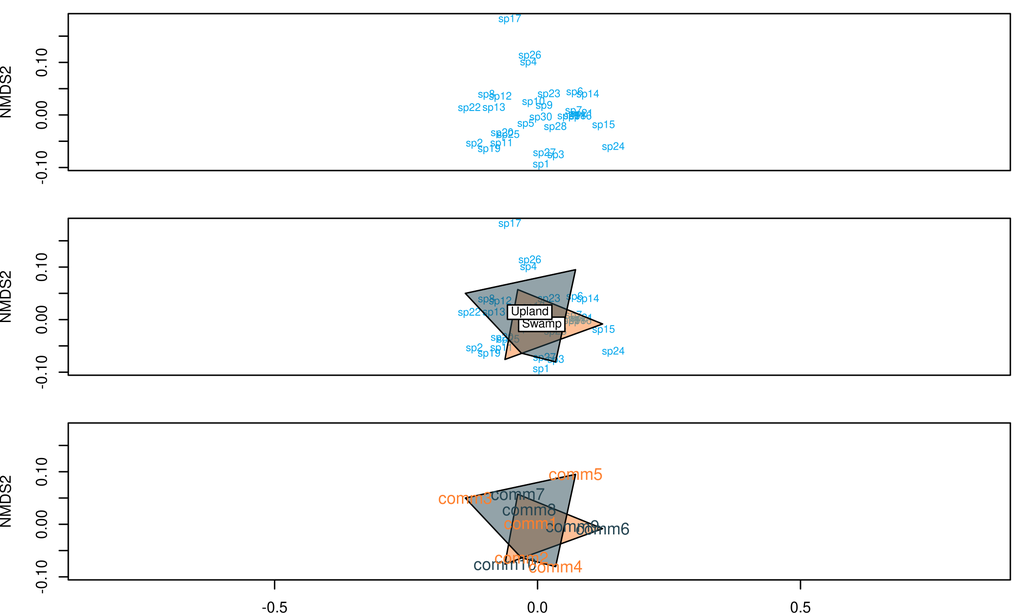